# Functional PCA

# GAM

## Procedure overview

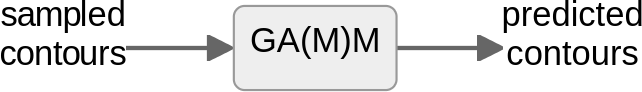

- Compact model of modes of shape variations
- Compact parametrisation of each curve in the dataset
- Regression model predicting curve shapes from factors

## GAM Outcome

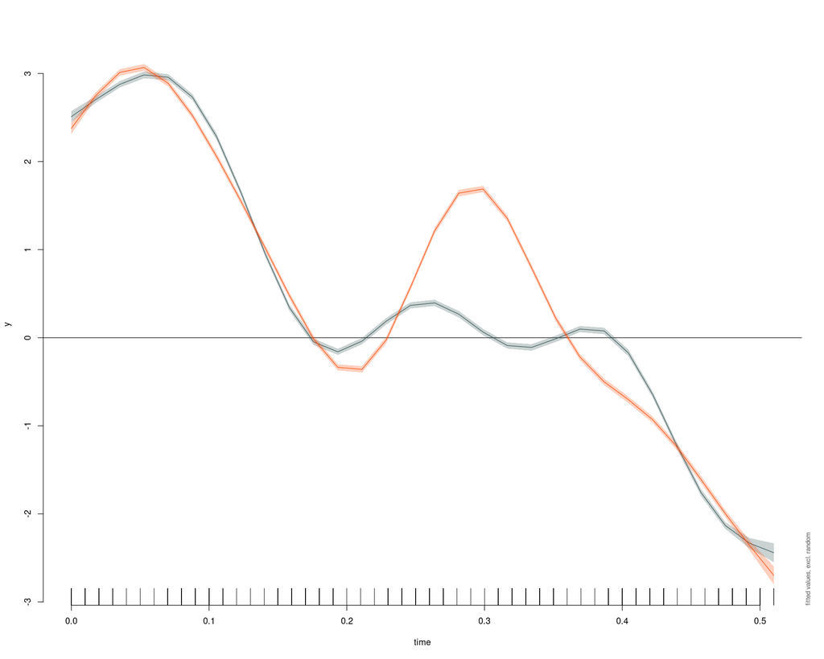

# Alternative workflows

## Processing PC scores

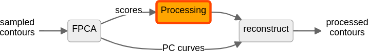

- If you have categories:
  - CART, Random forest, etc.
- If you don’t have categories:
  - clustering

## Proportion of variance

- PCs are ordered by proportion of explained variance in the curve dataset
- In our example, PC1 explains 51% of var., PC2 35%, etc.
- This variance has nothing to do with the categories
- A linear regression model `s1 ~ Category` explains 94% of the variance
- A linear regression model `s2 ~ Category` explains 1% of the variance
- This variance is the capacity of categories to predict a score
- These two types of variance have nothing to do with each other!

# Multi-dimensional curves

## A 2-dimensional curve dataset

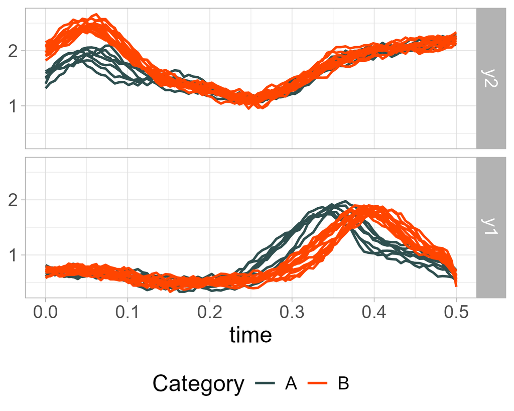

## D-dimensional Principal Components

- There are D mean curves
  - $\mu_{y1}(t)$ and $\mu_{y2}(t)$
- Each PC is composed of D curves
  - $PC1_{y1}(t)$ and $PC1_{y2}(t)$, $PC2_{y1}(t)$ and $PC2_{y2}(t)$, etc.
- Scores do not split in D
- Each score controls a PC, which is made of D 1-dimensional curves
  - $s_1$ controls (i.e. multiplies) $PC1_{y1}(t)$ and $PC1_{y2}(t)$

## Principal Components (PCs)

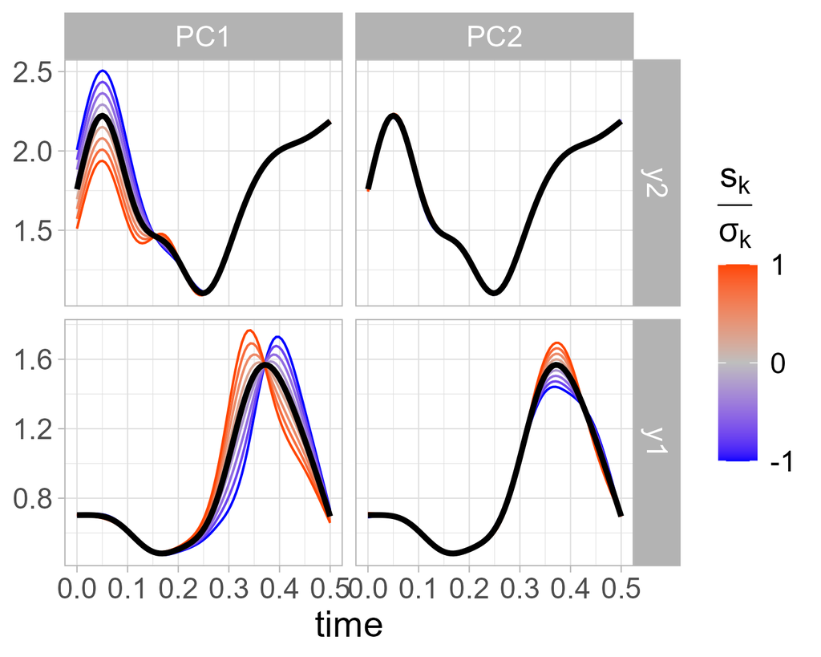

## PC scores v. Category

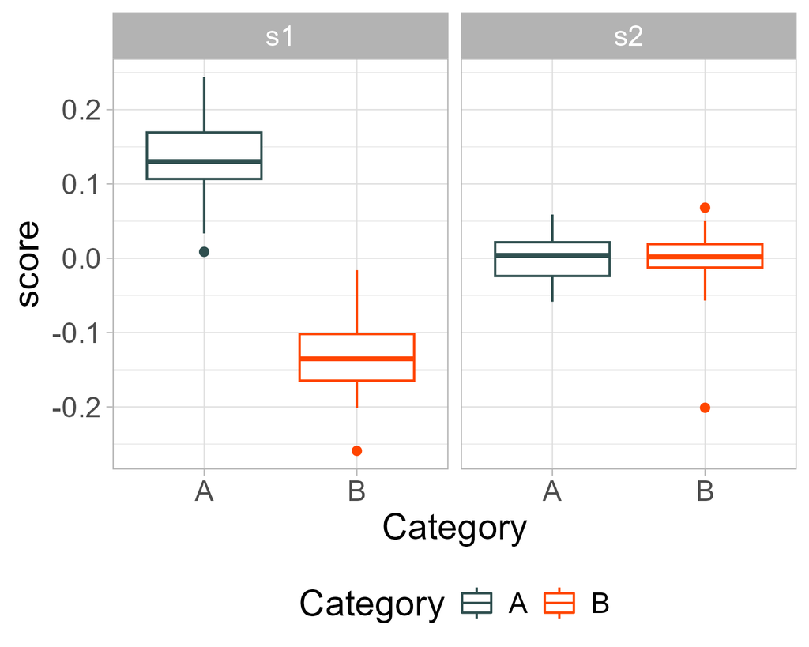

## Fit a regression model on s1

```r
mod <- lm(s1 ~ Category, data = PCscores)
emmeans(mod, pairwise ~ Category)
```

| Category | $s_1$ |
| --- | --- |
| A | 0.134 |
| B | -0.134 |

## Reconstruct predicted curves from s1

$$y1_A(t) = \mu_{y1}(t) + \color{red}{s_{1, A}} \cdot PC1_{y1}(t)$$
$$y2_A(t) = \mu_{y2}(t) + \color{red}{s_{1, A}} \cdot PC1_{y2}(t)$$

$$y1_B(t) = \mu_{y1}(t) + \color{red}{s_{1, B}} \cdot PC1_{y1}(t)$$
$$y2_B(t) = \mu_{y2}(t) + \color{red}{s_{1, B}} \cdot PC1_{y2}(t)$$

## Reconstruct predicted curves from s1

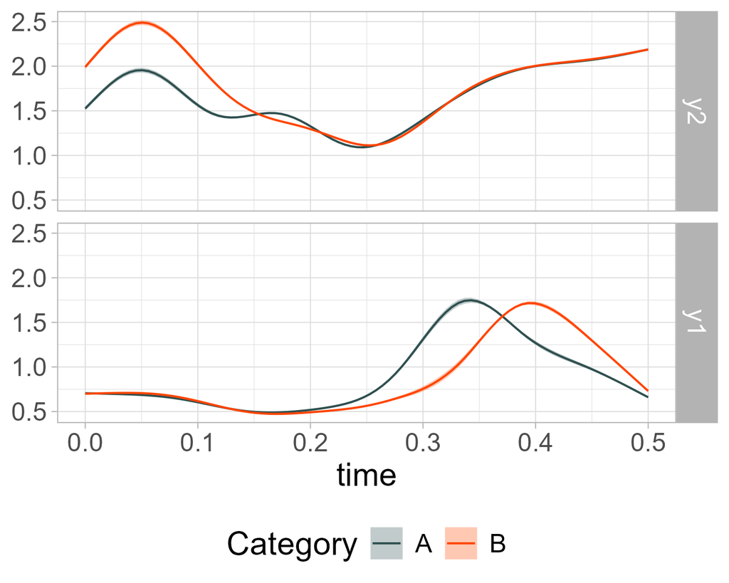

## Comments

- Contours are multidimensional
- PC scores behave as in uni-dimensional case
- Flexible and computationally cheap
- Difficult to obtain the same result with GAMs

## References

Arvaniti, Amalia, Argyro Katsika, and Na Hu. 2024. “Variability, Overlap, and Cue Trading in Intonation.” *Language* 100 (2): 265–307.

Asano, Yuki, and Michele Gubian. 2018. “‘Excuse Meeee!!’:(mis) Coordination of Lexical and Paralinguistic Prosody in L2 Hyperarticulation.” *Speech Communication* 99: 183–200.

Asano, Yuki, Michele Gubian, and Sacha Dominik. 2016. “Cutting down on Manual Pitch Contour Annotation Using Data Modelling.”

Cole, Jennifer, Jeremy Steffman, and Aya Awwad. 2024. “Functional Modeling of F0 Variation Across Speakers and Between Phonological Categories: Rising Pitch Accents in American English.” In *Speech Prosody 2024*, 1020–24. International Speech Communication Association (ISCA).

Cronenberg, Johanna, Michele Gubian, Jonathan Harrington, and Hanna Ruch. 2020. “A Dynamic Model of the Change from Pre-to Post-Aspiration in Andalusian Spanish.” *Journal of Phonetics* 83: 101016.

El Zarka, Dina, Anneliese Kelterer, Michele Gubian, and Barbara Schuppler. 2024. “The Prosody of Theme, Rheme and Focus in Egyptian Arabic: A Quantitative Investigation of Tunes, Configurations and Speaker Variability.” *Speech Communication*, 103082.

Gubian, Michele, Lou Boves, and Francesco Cangemi. 2011. “Joint Analysis of f 0 and Speech Rate with Functional Data Analysis.” In *2011 IEEE International Conference on Acoustics, Speech and Signal Processing (ICASSP)*, 4972–75. IEEE.

Gubian, Michele, Francesco Cangemi, and Lou Boves. 2010. “Automatic and Data Driven Pitch Contour Manipulation with Functional Data Analysis.”

Gubian, Michele, Jonathan Harrington, Mary Stevens, Florian Schiel, and Paul Warren. 2019. “Tracking the New Zealand English near/square Merger Using Functional Principal Components Analysis.” In *Proceedings of the 20th Annual Conference of the International Speech Communication Association*, 296–300. Graz. https://doi.org/10.21437/Interspeech.2019-2115.

Gubian, Michele, Manfred Pastätter, and Marianne Pouplier. 2019. “Zooming in on Spatiotemporal v-to-c Coarticulation with Functional PCA.” In *INTERSPEECH*, 889–93.

Gubian, Michele, Francisco Torreira, and Lou Boves. 2015. “Using Functional Data Analysis for Investigating Multidimensional Dynamic Phonetic Contrasts.” *Journal of Phonetics* 49: 16–40. https://doi.org/10.1016/j.wocn.2014.10.001.

Maspong, Sireemas, Patrick McCormick, and James Kirby. 2025. “Voice Register in Mon: Experiments in Production and Perception.” *Phonetica* 82 (3): 181–233.

Ramsay, J., and B. Silverman. 2005. *Functional Data Analysis*. Springer Series in Statistics.